# Risk Factor Analysis

## Outcome Variable

**Outcome Variable:** sstunted

## Predictor Variables

**Intervention Variable:** month

**Adjustment Set:**

unadjusted

## Stratifying Variables

The analysis was stratified on these variable(s):

- agecat
- studyid
- country

## Data Summary

| agecat | studyid | country | month | sstunted | n_cell | n |
| --- | --- | --- | --- | --- | --- | --- |
| Birth | ki0047075b-MAL-ED | BANGLADESH | 1 | 0 | 19 | 257 |
| Birth | ki0047075b-MAL-ED | BANGLADESH | 1 | 1 | 0 | 257 |
| Birth | ki0047075b-MAL-ED | BANGLADESH | 2 | 0 | 23 | 257 |
| Birth | ki0047075b-MAL-ED | BANGLADESH | 2 | 1 | 1 | 257 |
| Birth | ki0047075b-MAL-ED | BANGLADESH | 3 | 0 | 28 | 257 |
| Birth | ki0047075b-MAL-ED | BANGLADESH | 3 | 1 | 0 | 257 |
| Birth | ki0047075b-MAL-ED | BANGLADESH | 4 | 0 | 21 | 257 |
| Birth | ki0047075b-MAL-ED | BANGLADESH | 4 | 1 | 0 | 257 |
| Birth | ki0047075b-MAL-ED | BANGLADESH | 5 | 0 | 19 | 257 |
| Birth | ki0047075b-MAL-ED | BANGLADESH | 5 | 1 | 2 | 257 |
| Birth | ki0047075b-MAL-ED | BANGLADESH | 6 | 0 | 9 | 257 |
| Birth | ki0047075b-MAL-ED | BANGLADESH | 6 | 1 | 0 | 257 |
| Birth | ki0047075b-MAL-ED | BANGLADESH | 7 | 0 | 21 | 257 |
| Birth | ki0047075b-MAL-ED | BANGLADESH | 7 | 1 | 1 | 257 |
| Birth | ki0047075b-MAL-ED | BANGLADESH | 8 | 0 | 22 | 257 |
| Birth | ki0047075b-MAL-ED | BANGLADESH | 8 | 1 | 3 | 257 |
| Birth | ki0047075b-MAL-ED | BANGLADESH | 9 | 0 | 21 | 257 |
| Birth | ki0047075b-MAL-ED | BANGLADESH | 9 | 1 | 1 | 257 |
| Birth | ki0047075b-MAL-ED | BANGLADESH | 10 | 0 | 24 | 257 |
| Birth | ki0047075b-MAL-ED | BANGLADESH | 10 | 1 | 0 | 257 |
| Birth | ki0047075b-MAL-ED | BANGLADESH | 11 | 0 | 15 | 257 |
| Birth | ki0047075b-MAL-ED | BANGLADESH | 11 | 1 | 0 | 257 |
| Birth | ki0047075b-MAL-ED | BANGLADESH | 12 | 0 | 26 | 257 |
| Birth | ki0047075b-MAL-ED | BANGLADESH | 12 | 1 | 1 | 257 |
| Birth | ki0047075b-MAL-ED | BRAZIL | 1 | 0 | 9 | 191 |
| Birth | ki0047075b-MAL-ED | BRAZIL | 1 | 1 | 0 | 191 |
| Birth | ki0047075b-MAL-ED | BRAZIL | 2 | 0 | 19 | 191 |
| Birth | ki0047075b-MAL-ED | BRAZIL | 2 | 1 | 2 | 191 |
| Birth | ki0047075b-MAL-ED | BRAZIL | 3 | 0 | 17 | 191 |
| Birth | ki0047075b-MAL-ED | BRAZIL | 3 | 1 | 1 | 191 |

[output cut: 1626 more lines]

The following strata were considered:

- agecat: 24 months, studyid: ki0047075b-MAL-ED, country: BANGLADESH
- agecat: 24 months, studyid: ki0047075b-MAL-ED, country: BRAZIL
- agecat: 24 months, studyid: ki0047075b-MAL-ED, country: INDIA
- agecat: 24 months, studyid: ki0047075b-MAL-ED, country: NEPAL
- agecat: 24 months, studyid: ki0047075b-MAL-ED, country: PERU
- agecat: 24 months, studyid: ki0047075b-MAL-ED, country: SOUTH AFRICA
- agecat: 24 months, studyid: ki0047075b-MAL-ED, country: TANZANIA, UNITED REPUBLIC OF
- agecat: 24 months, studyid: ki1000108-CMC-V-BCS-2002, country: INDIA
- agecat: 24 months, studyid: ki1000108-IRC, country: INDIA
- agecat: 24 months, studyid: ki1017093-NIH-Birth, country: BANGLADESH
- agecat: 24 months, studyid: ki1066203-TanzaniaChild2, country: TANZANIA, UNITED REPUBLIC OF
- agecat: 24 months, studyid: ki1113344-GMS-Nepal, country: NEPAL
- agecat: 24 months, studyid: ki1114097-CMIN, country: BANGLADESH
- agecat: 24 months, studyid: ki1114097-CMIN, country: GUINEA-BISSAU
- agecat: 24 months, studyid: ki1114097-CMIN, country: PERU
- agecat: 24 months, studyid: ki1114097-CONTENT, country: PERU
- agecat: 24 months, studyid: ki1119695-PROBIT, country: BELARUS
- agecat: 24 months, studyid: ki1126311-ZVITAMBO, country: ZIMBABWE
- agecat: 24 months, studyid: ki1148112-LCNI-5, country: MALAWI
- agecat: 24 months, studyid: kiGH5241-JiVitA-3, country: BANGLADESH
- agecat: 24 months, studyid: kiGH5241-JiVitA-4, country: BANGLADESH
- agecat: 6 months, studyid: ki0047075b-MAL-ED, country: BANGLADESH
- agecat: 6 months, studyid: ki0047075b-MAL-ED, country: BRAZIL
- agecat: 6 months, studyid: ki0047075b-MAL-ED, country: INDIA
- agecat: 6 months, studyid: ki0047075b-MAL-ED, country: NEPAL
- agecat: 6 months, studyid: ki0047075b-MAL-ED, country: PERU
- agecat: 6 months, studyid: ki0047075b-MAL-ED, country: SOUTH AFRICA
- agecat: 6 months, studyid: ki0047075b-MAL-ED, country: TANZANIA, UNITED REPUBLIC OF
- agecat: 6 months, studyid: ki1000108-CMC-V-BCS-2002, country: INDIA
- agecat: 6 months, studyid: ki1000108-IRC, country: INDIA
- agecat: 6 months, studyid: ki1000109-EE, country: PAKISTAN
- agecat: 6 months, studyid: ki1000109-ResPak, country: PAKISTAN
- agecat: 6 months, studyid: ki1000304b-SAS-CompFeed, country: INDIA
- agecat: 6 months, studyid: ki1000304b-SAS-FoodSuppl, country: INDIA
- agecat: 6 months, studyid: ki1017093-NIH-Birth, country: BANGLADESH
- agecat: 6 months, studyid: ki1066203-TanzaniaChild2, country: TANZANIA, UNITED REPUBLIC OF
- agecat: 6 months, studyid: ki1112895-Guatemala BSC, country: GUATEMALA
- agecat: 6 months, studyid: ki1113344-GMS-Nepal, country: NEPAL
- agecat: 6 months, studyid: ki1114097-CMIN, country: BANGLADESH
- agecat: 6 months, studyid: ki1114097-CMIN, country: BRAZIL
- agecat: 6 months, studyid: ki1114097-CMIN, country: GUINEA-BISSAU
- agecat: 6 months, studyid: ki1114097-CMIN, country: PERU
- agecat: 6 months, studyid: ki1114097-CONTENT, country: PERU
- agecat: 6 months, studyid: ki1119695-PROBIT, country: BELARUS
- agecat: 6 months, studyid: ki1126311-ZVITAMBO, country: ZIMBABWE
- agecat: 6 months, studyid: ki1148112-LCNI-5, country: MALAWI
- agecat: 6 months, studyid: kiGH5241-JiVitA-3, country: BANGLADESH
- agecat: 6 months, studyid: kiGH5241-JiVitA-4, country: BANGLADESH
- agecat: Birth, studyid: ki0047075b-MAL-ED, country: BANGLADESH
- agecat: Birth, studyid: ki0047075b-MAL-ED, country: BRAZIL
- agecat: Birth, studyid: ki0047075b-MAL-ED, country: INDIA
- agecat: Birth, studyid: ki0047075b-MAL-ED, country: NEPAL
- agecat: Birth, studyid: ki0047075b-MAL-ED, country: PERU
- agecat: Birth, studyid: ki0047075b-MAL-ED, country: SOUTH AFRICA
- agecat: Birth, studyid: ki0047075b-MAL-ED, country: TANZANIA, UNITED REPUBLIC OF
- agecat: Birth, studyid: ki1000108-CMC-V-BCS-2002, country: INDIA
- agecat: Birth, studyid: ki1000108-IRC, country: INDIA
- agecat: Birth, studyid: ki1000109-EE, country: PAKISTAN
- agecat: Birth, studyid: ki1000109-ResPak, country: PAKISTAN
- agecat: Birth, studyid: ki1000304b-SAS-CompFeed, country: INDIA
- agecat: Birth, studyid: ki1017093-NIH-Birth, country: BANGLADESH
- agecat: Birth, studyid: ki1114097-CMIN, country: BANGLADESH
- agecat: Birth, studyid: ki1114097-CMIN, country: BRAZIL
- agecat: Birth, studyid: ki1114097-CMIN, country: PERU
- agecat: Birth, studyid: ki1114097-CONTENT, country: PERU
- agecat: Birth, studyid: ki1119695-PROBIT, country: BELARUS
- agecat: Birth, studyid: ki1126311-ZVITAMBO, country: ZIMBABWE
- agecat: Birth, studyid: kiGH5241-JiVitA-3, country: BANGLADESH
- agecat: Birth, studyid: kiGH5241-JiVitA-4, country: BANGLADESH

### Dropped Strata

Some strata were dropped due to rare outcomes:

- agecat: Birth, studyid: ki0047075b-MAL-ED, country: BANGLADESH
- agecat: Birth, studyid: ki0047075b-MAL-ED, country: BRAZIL
- agecat: Birth, studyid: ki0047075b-MAL-ED, country: INDIA
- agecat: Birth, studyid: ki0047075b-MAL-ED, country: NEPAL
- agecat: Birth, studyid: ki0047075b-MAL-ED, country: PERU
- agecat: Birth, studyid: ki0047075b-MAL-ED, country: SOUTH AFRICA
- agecat: Birth, studyid: ki0047075b-MAL-ED, country: TANZANIA, UNITED REPUBLIC OF
- agecat: Birth, studyid: ki1000108-CMC-V-BCS-2002, country: INDIA
- agecat: Birth, studyid: ki1000108-IRC, country: INDIA
- agecat: Birth, studyid: ki1000109-EE, country: PAKISTAN
- agecat: Birth, studyid: ki1000109-ResPak, country: PAKISTAN
- agecat: Birth, studyid: ki1000304b-SAS-CompFeed, country: INDIA
- agecat: Birth, studyid: ki1017093-NIH-Birth, country: BANGLADESH
- agecat: Birth, studyid: ki1114097-CMIN, country: BANGLADESH
- agecat: Birth, studyid: ki1114097-CMIN, country: BRAZIL
- agecat: Birth, studyid: ki1114097-CMIN, country: PERU
- agecat: Birth, studyid: ki1114097-CONTENT, country: PERU
- agecat: Birth, studyid: ki1119695-PROBIT, country: BELARUS
- agecat: Birth, studyid: kiGH5241-JiVitA-4, country: BANGLADESH
- agecat: 6 months, studyid: ki0047075b-MAL-ED, country: BANGLADESH
- agecat: 6 months, studyid: ki0047075b-MAL-ED, country: BRAZIL
- agecat: 6 months, studyid: ki0047075b-MAL-ED, country: INDIA
- agecat: 6 months, studyid: ki0047075b-MAL-ED, country: NEPAL
- agecat: 6 months, studyid: ki0047075b-MAL-ED, country: PERU
- agecat: 6 months, studyid: ki0047075b-MAL-ED, country: SOUTH AFRICA
- agecat: 6 months, studyid: ki0047075b-MAL-ED, country: TANZANIA, UNITED REPUBLIC OF
- agecat: 6 months, studyid: ki1000108-CMC-V-BCS-2002, country: INDIA
- agecat: 6 months, studyid: ki1000108-IRC, country: INDIA
- agecat: 6 months, studyid: ki1000109-EE, country: PAKISTAN
- agecat: 6 months, studyid: ki1000109-ResPak, country: PAKISTAN
- agecat: 6 months, studyid: ki1000304b-SAS-CompFeed, country: INDIA
- agecat: 6 months, studyid: ki1000304b-SAS-FoodSuppl, country: INDIA
- agecat: 6 months, studyid: ki1017093-NIH-Birth, country: BANGLADESH
- agecat: 6 months, studyid: ki1066203-TanzaniaChild2, country: TANZANIA, UNITED REPUBLIC OF
- agecat: 6 months, studyid: ki1112895-Guatemala BSC, country: GUATEMALA
- agecat: 6 months, studyid: ki1113344-GMS-Nepal, country: NEPAL
- agecat: 6 months, studyid: ki1114097-CMIN, country: BANGLADESH
- agecat: 6 months, studyid: ki1114097-CMIN, country: BRAZIL
- agecat: 6 months, studyid: ki1114097-CMIN, country: GUINEA-BISSAU
- agecat: 6 months, studyid: ki1114097-CMIN, country: PERU
- agecat: 6 months, studyid: ki1114097-CONTENT, country: PERU
- agecat: 6 months, studyid: ki1148112-LCNI-5, country: MALAWI
- agecat: 6 months, studyid: kiGH5241-JiVitA-4, country: BANGLADESH
- agecat: 24 months, studyid: ki0047075b-MAL-ED, country: BANGLADESH
- agecat: 24 months, studyid: ki0047075b-MAL-ED, country: BRAZIL
- agecat: 24 months, studyid: ki0047075b-MAL-ED, country: INDIA
- agecat: 24 months, studyid: ki0047075b-MAL-ED, country: NEPAL
- agecat: 24 months, studyid: ki0047075b-MAL-ED, country: PERU
- agecat: 24 months, studyid: ki0047075b-MAL-ED, country: SOUTH AFRICA
- agecat: 24 months, studyid: ki0047075b-MAL-ED, country: TANZANIA, UNITED REPUBLIC OF
- agecat: 24 months, studyid: ki1000108-CMC-V-BCS-2002, country: INDIA
- agecat: 24 months, studyid: ki1000108-IRC, country: INDIA
- agecat: 24 months, studyid: ki1017093-NIH-Birth, country: BANGLADESH
- agecat: 24 months, studyid: ki1066203-TanzaniaChild2, country: TANZANIA, UNITED REPUBLIC OF
- agecat: 24 months, studyid: ki1113344-GMS-Nepal, country: NEPAL
- agecat: 24 months, studyid: ki1114097-CMIN, country: BANGLADESH
- agecat: 24 months, studyid: ki1114097-CMIN, country: GUINEA-BISSAU
- agecat: 24 months, studyid: ki1114097-CMIN, country: PERU
- agecat: 24 months, studyid: ki1114097-CONTENT, country: PERU
- agecat: 24 months, studyid: ki1119695-PROBIT, country: BELARUS
- agecat: 24 months, studyid: ki1126311-ZVITAMBO, country: ZIMBABWE
- agecat: 24 months, studyid: ki1148112-LCNI-5, country: MALAWI
- agecat: 24 months, studyid: kiGH5241-JiVitA-4, country: BANGLADESH

## Methods Detail

We’re interested in the causal parameters $E[Y_a]$ for all values of $a \in \mathcal{A}$. These parameters represent the mean outcome if, possibly contrary to fact, we intervened to set all units to have $A=a$. Under the randomization and positivity assumptions, these are identified by the statistical parameters $\psi_a=E_W[E_{Y|A,W}(Y|A=a,W)]$. In addition, we’re interested in the mean of $Y$, $E[Y]$ under no intervention (the observed mean). We will estimate these parameters by using SuperLearner to fit the relevant likelihood factors – $E_{Y|A,W}(Y|A=a,W)$ and $p(A=a|W)$, and then updating our likelihood fit using a joint TMLE.

For unadjusted analyses ($W=\{\}$), initial likelihoods were estimated using Lrnr_glm to estimate the simple $E(Y|A)$ and Lrnr_mean to estimate $p(A)$. For adjusted analyses, a small library containing Lrnr_glmnet, Lrnr_xgboost, and Lrnr_mean was used.

Having estimated these parameters, we will then use the delta method to estimate relative risks and attributable risks relative to a prespecified baseline level of $A$.

# Results Detail

## Results Plots

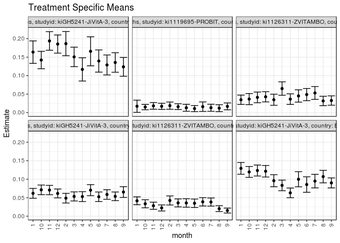

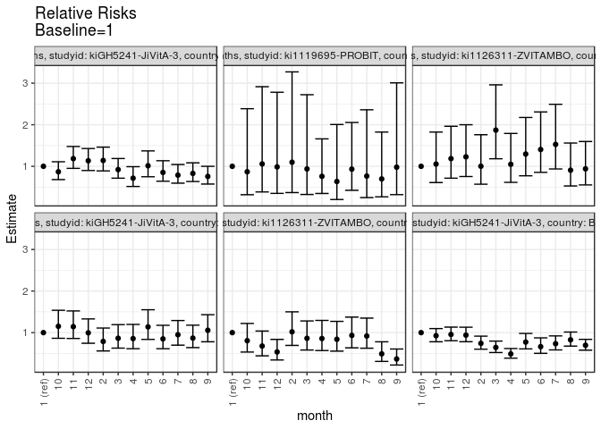

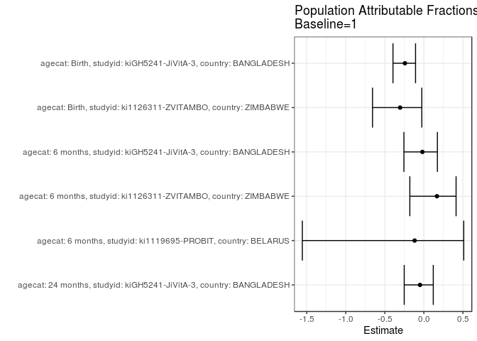

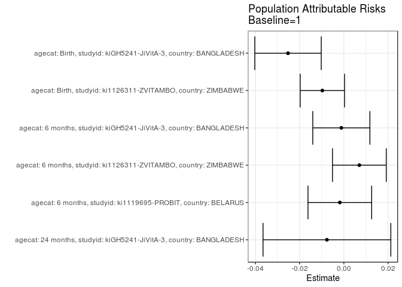

## Results Table

### Parameter: TSM

| agecat | studyid | country | intervention_level | baseline_level | estimate | ci_lower | ci_upper |
| --- | --- | --- | --- | --- | --- | --- | --- |
| Birth | ki1126311-ZVITAMBO | ZIMBABWE | 1 | NA | 0.0416667 | 0.0309831 | 0.0523502 |
| Birth | ki1126311-ZVITAMBO | ZIMBABWE | 2 | NA | 0.0424710 | 0.0301908 | 0.0547513 |
| Birth | ki1126311-ZVITAMBO | ZIMBABWE | 3 | NA | 0.0359649 | 0.0251556 | 0.0467742 |
| Birth | ki1126311-ZVITAMBO | ZIMBABWE | 4 | NA | 0.0357498 | 0.0242819 | 0.0472176 |
| Birth | ki1126311-ZVITAMBO | ZIMBABWE | 5 | NA | 0.0350000 | 0.0236090 | 0.0463910 |
| Birth | ki1126311-ZVITAMBO | ZIMBABWE | 6 | NA | 0.0388693 | 0.0276093 | 0.0501292 |
| Birth | ki1126311-ZVITAMBO | ZIMBABWE | 7 | NA | 0.0382653 | 0.0273008 | 0.0492298 |
| Birth | ki1126311-ZVITAMBO | ZIMBABWE | 8 | NA | 0.0203915 | 0.0124798 | 0.0283032 |
| Birth | ki1126311-ZVITAMBO | ZIMBABWE | 9 | NA | 0.0152323 | 0.0086074 | 0.0218572 |
| Birth | ki1126311-ZVITAMBO | ZIMBABWE | 10 | NA | 0.0335893 | 0.0226494 | 0.0445291 |
| Birth | ki1126311-ZVITAMBO | ZIMBABWE | 11 | NA | 0.0282187 | 0.0185802 | 0.0378572 |
| Birth | ki1126311-ZVITAMBO | ZIMBABWE | 12 | NA | 0.0223108 | 0.0141393 | 0.0304822 |
| Birth | kiGH5241-JiVitA-3 | BANGLADESH | 1 | NA | 0.1293058 | 0.1133816 | 0.1452299 |
| Birth | kiGH5241-JiVitA-3 | BANGLADESH | 2 | NA | 0.0959079 | 0.0796430 | 0.1121729 |
| Birth | kiGH5241-JiVitA-3 | BANGLADESH | 3 | NA | 0.0832888 | 0.0689004 | 0.0976773 |
| Birth | kiGH5241-JiVitA-3 | BANGLADESH | 4 | NA | 0.0630499 | 0.0499428 | 0.0761569 |
| Birth | kiGH5241-JiVitA-3 | BANGLADESH | 5 | NA | 0.0998959 | 0.0794255 | 0.1203664 |
| Birth | kiGH5241-JiVitA-3 | BANGLADESH | 6 | NA | 0.0855992 | 0.0647497 | 0.1064487 |
| Birth | kiGH5241-JiVitA-3 | BANGLADESH | 7 | NA | 0.0948435 | 0.0765394 | 0.1131475 |
| Birth | kiGH5241-JiVitA-3 | BANGLADESH | 8 | NA | 0.1070234 | 0.0900786 | 0.1239682 |
| Birth | kiGH5241-JiVitA-3 | BANGLADESH | 9 | NA | 0.0899839 | 0.0764511 | 0.1035167 |
| Birth | kiGH5241-JiVitA-3 | BANGLADESH | 10 | NA | 0.1196420 | 0.1049114 | 0.1343726 |
| Birth | kiGH5241-JiVitA-3 | BANGLADESH | 11 | NA | 0.1235023 | 0.1086803 | 0.1383244 |
| Birth | kiGH5241-JiVitA-3 | BANGLADESH | 12 | NA | 0.1215247 | 0.1059686 | 0.1370807 |
| 6 months | ki1119695-PROBIT | BELARUS | 1 | NA | 0.0172414 | 0.0007512 | 0.0337316 |
| 6 months | ki1119695-PROBIT | BELARUS | 2 | NA | 0.0189274 | 0.0091703 | 0.0286846 |
| 6 months | ki1119695-PROBIT | BELARUS | 3 | NA | 0.0161580 | 0.0082849 | 0.0240311 |
| 6 months | ki1119695-PROBIT | BELARUS | 4 | NA | 0.0130841 | 0.0037456 | 0.0224226 |
| 6 months | ki1119695-PROBIT | BELARUS | 5 | NA | 0.0109489 | 0.0027783 | 0.0191195 |
| 6 months | ki1119695-PROBIT | BELARUS | 6 | NA | 0.0160714 | 0.0032535 | 0.0288894 |
| 6 months | ki1119695-PROBIT | BELARUS | 7 | NA | 0.0131868 | 0.0037091 | 0.0226646 |
| 6 months | ki1119695-PROBIT | BELARUS | 8 | NA | 0.0120160 | 0.0027054 | 0.0213267 |
| 6 months | ki1119695-PROBIT | BELARUS | 9 | NA | 0.0168805 | 0.0076294 | 0.0261315 |
| 6 months | ki1119695-PROBIT | BELARUS | 10 | NA | 0.0149880 | 0.0078128 | 0.0221633 |
| 6 months | ki1119695-PROBIT | BELARUS | 11 | NA | 0.0182390 | 0.0092779 | 0.0272001 |
| 6 months | ki1119695-PROBIT | BELARUS | 12 | NA | 0.0169988 | 0.0086663 | 0.0253313 |
| 6 months | ki1126311-ZVITAMBO | ZIMBABWE | 1 | NA | 0.0347826 | 0.0221245 | 0.0474408 |
| 6 months | ki1126311-ZVITAMBO | ZIMBABWE | 2 | NA | 0.0348432 | 0.0198403 | 0.0498461 |
| 6 months | ki1126311-ZVITAMBO | ZIMBABWE | 3 | NA | 0.0650636 | 0.0468824 | 0.0832449 |
| 6 months | ki1126311-ZVITAMBO | ZIMBABWE | 4 | NA | 0.0364742 | 0.0221495 | 0.0507989 |
| 6 months | ki1126311-ZVITAMBO | ZIMBABWE | 5 | NA | 0.0450751 | 0.0284596 | 0.0616906 |
| 6 months | ki1126311-ZVITAMBO | ZIMBABWE | 6 | NA | 0.0488550 | 0.0323456 | 0.0653644 |
| 6 months | ki1126311-ZVITAMBO | ZIMBABWE | 7 | NA | 0.0531250 | 0.0357478 | 0.0705022 |
| 6 months | ki1126311-ZVITAMBO | ZIMBABWE | 8 | NA | 0.0315501 | 0.0188604 | 0.0442397 |
| 6 months | ki1126311-ZVITAMBO | ZIMBABWE | 9 | NA | 0.0326797 | 0.0200798 | 0.0452797 |
| 6 months | ki1126311-ZVITAMBO | ZIMBABWE | 10 | NA | 0.0366667 | 0.0216275 | 0.0517058 |
| 6 months | ki1126311-ZVITAMBO | ZIMBABWE | 11 | NA | 0.0412088 | 0.0267688 | 0.0556487 |
| 6 months | ki1126311-ZVITAMBO | ZIMBABWE | 12 | NA | 0.0427350 | 0.0288821 | 0.0565879 |
| 6 months | kiGH5241-JiVitA-3 | BANGLADESH | 1 | NA | 0.0618102 | 0.0484754 | 0.0751449 |
| 6 months | kiGH5241-JiVitA-3 | BANGLADESH | 2 | NA | 0.0486986 | 0.0356105 | 0.0617866 |
| 6 months | kiGH5241-JiVitA-3 | BANGLADESH | 3 | NA | 0.0534459 | 0.0411684 | 0.0657233 |
| 6 months | kiGH5241-JiVitA-3 | BANGLADESH | 4 | NA | 0.0529412 | 0.0395066 | 0.0663758 |
| 6 months | kiGH5241-JiVitA-3 | BANGLADESH | 5 | NA | 0.0703736 | 0.0554174 | 0.0853298 |
| 6 months | kiGH5241-JiVitA-3 | BANGLADESH | 6 | NA | 0.0524957 | 0.0396305 | 0.0653609 |
| 6 months | kiGH5241-JiVitA-3 | BANGLADESH | 7 | NA | 0.0586817 | 0.0457542 | 0.0716091 |
| 6 months | kiGH5241-JiVitA-3 | BANGLADESH | 8 | NA | 0.0536685 | 0.0419857 | 0.0653513 |
| 6 months | kiGH5241-JiVitA-3 | BANGLADESH | 9 | NA | 0.0653009 | 0.0507635 | 0.0798383 |
| 6 months | kiGH5241-JiVitA-3 | BANGLADESH | 10 | NA | 0.0712166 | 0.0581941 | 0.0842391 |
| 6 months | kiGH5241-JiVitA-3 | BANGLADESH | 11 | NA | 0.0706714 | 0.0580368 | 0.0833059 |
| 6 months | kiGH5241-JiVitA-3 | BANGLADESH | 12 | NA | 0.0614925 | 0.0495543 | 0.0734308 |
| 24 months | kiGH5241-JiVitA-3 | BANGLADESH | 1 | NA | 0.1635846 | 0.1332322 | 0.1939371 |
| 24 months | kiGH5241-JiVitA-3 | BANGLADESH | 2 | NA | 0.1865794 | 0.1538710 | 0.2192877 |
| 24 months | kiGH5241-JiVitA-3 | BANGLADESH | 3 | NA | 0.1506849 | 0.1243811 | 0.1769888 |
| 24 months | kiGH5241-JiVitA-3 | BANGLADESH | 4 | NA | 0.1168831 | 0.0854611 | 0.1483052 |
| 24 months | kiGH5241-JiVitA-3 | BANGLADESH | 5 | NA | 0.1658291 | 0.1265790 | 0.2050793 |
| 24 months | kiGH5241-JiVitA-3 | BANGLADESH | 6 | NA | 0.1395760 | 0.1095218 | 0.1696301 |
| 24 months | kiGH5241-JiVitA-3 | BANGLADESH | 7 | NA | 0.1288820 | 0.1018563 | 0.1559077 |
| 24 months | kiGH5241-JiVitA-3 | BANGLADESH | 8 | NA | 0.1355932 | 0.1092602 | 0.1619263 |
| 24 months | kiGH5241-JiVitA-3 | BANGLADESH | 9 | NA | 0.1238095 | 0.0984021 | 0.1492169 |
| 24 months | kiGH5241-JiVitA-3 | BANGLADESH | 10 | NA | 0.1422071 | 0.1186662 | 0.1657479 |
| 24 months | kiGH5241-JiVitA-3 | BANGLADESH | 11 | NA | 0.1938144 | 0.1686426 | 0.2189863 |
| 24 months | kiGH5241-JiVitA-3 | BANGLADESH | 12 | NA | 0.1854305 | 0.1608542 | 0.2100068 |

### Parameter: E(Y)

| agecat | studyid | country | intervention_level | baseline_level | estimate | ci_lower | ci_upper |
| --- | --- | --- | --- | --- | --- | --- | --- |
| Birth | ki1126311-ZVITAMBO | ZIMBABWE | NA | NA | 0.0319449 | 0.0290114 | 0.0348785 |
| Birth | kiGH5241-JiVitA-3 | BANGLADESH | NA | NA | 0.1040636 | 0.0993965 | 0.1087307 |
| 6 months | ki1119695-PROBIT | BELARUS | NA | NA | 0.0154178 | 0.0100323 | 0.0208033 |
| 6 months | ki1126311-ZVITAMBO | ZIMBABWE | NA | NA | 0.0417925 | 0.0374816 | 0.0461034 |
| 6 months | kiGH5241-JiVitA-3 | BANGLADESH | NA | NA | 0.0606746 | 0.0568229 | 0.0645262 |
| 24 months | kiGH5241-JiVitA-3 | BANGLADESH | NA | NA | 0.1559314 | 0.1471744 | 0.1646884 |

### Parameter: RR

| agecat | studyid | country | intervention_level | baseline_level | estimate | ci_lower | ci_upper |
| --- | --- | --- | --- | --- | --- | --- | --- |
| Birth | ki1126311-ZVITAMBO | ZIMBABWE | 1 | 1 | 1.0000000 | 1.0000000 | 1.0000000 |
| Birth | ki1126311-ZVITAMBO | ZIMBABWE | 2 | 1 | 1.0193050 | 0.6925779 | 1.5001674 |
| Birth | ki1126311-ZVITAMBO | ZIMBABWE | 3 | 1 | 0.8631579 | 0.5814555 | 1.2813390 |
| Birth | ki1126311-ZVITAMBO | ZIMBABWE | 4 | 1 | 0.8579940 | 0.5690307 | 1.2936978 |
| Birth | ki1126311-ZVITAMBO | ZIMBABWE | 5 | 1 | 0.8400000 | 0.5550597 | 1.2712146 |
| Birth | ki1126311-ZVITAMBO | ZIMBABWE | 6 | 1 | 0.9328622 | 0.6335856 | 1.3735032 |
| Birth | ki1126311-ZVITAMBO | ZIMBABWE | 7 | 1 | 0.9183673 | 0.6252089 | 1.3489868 |
| Birth | ki1126311-ZVITAMBO | ZIMBABWE | 8 | 1 | 0.4893964 | 0.3073889 | 0.7791721 |
| Birth | ki1126311-ZVITAMBO | ZIMBABWE | 9 | 1 | 0.3655751 | 0.2206529 | 0.6056806 |
| Birth | ki1126311-ZVITAMBO | ZIMBABWE | 10 | 1 | 0.8061420 | 0.5325874 | 1.2202035 |
| Birth | ki1126311-ZVITAMBO | ZIMBABWE | 11 | 1 | 0.6772487 | 0.4418379 | 1.0380861 |
| Birth | ki1126311-ZVITAMBO | ZIMBABWE | 12 | 1 | 0.5354582 | 0.3424188 | 0.8373238 |
| Birth | kiGH5241-JiVitA-3 | BANGLADESH | 1 | 1 | 1.0000000 | 1.0000000 | 1.0000000 |
| Birth | kiGH5241-JiVitA-3 | BANGLADESH | 2 | 1 | 0.7417142 | 0.6010868 | 0.9152421 |
| Birth | kiGH5241-JiVitA-3 | BANGLADESH | 3 | 1 | 0.6441231 | 0.5212212 | 0.7960049 |
| Birth | kiGH5241-JiVitA-3 | BANGLADESH | 4 | 1 | 0.4876028 | 0.3852610 | 0.6171309 |
| Birth | kiGH5241-JiVitA-3 | BANGLADESH | 5 | 1 | 0.7725559 | 0.6090118 | 0.9800182 |
| Birth | kiGH5241-JiVitA-3 | BANGLADESH | 6 | 1 | 0.6619905 | 0.5016719 | 0.8735419 |
| Birth | kiGH5241-JiVitA-3 | BANGLADESH | 7 | 1 | 0.7334820 | 0.5841629 | 0.9209690 |
| Birth | kiGH5241-JiVitA-3 | BANGLADESH | 8 | 1 | 0.8276770 | 0.6754864 | 1.0141568 |
| Birth | kiGH5241-JiVitA-3 | BANGLADESH | 9 | 1 | 0.6959003 | 0.5776959 | 0.8382910 |
| Birth | kiGH5241-JiVitA-3 | BANGLADESH | 10 | 1 | 0.9252643 | 0.7800104 | 1.0975673 |
| Birth | kiGH5241-JiVitA-3 | BANGLADESH | 11 | 1 | 0.9551182 | 0.8054851 | 1.1325484 |
| Birth | kiGH5241-JiVitA-3 | BANGLADESH | 12 | 1 | 0.9398239 | 0.7811675 | 1.1307038 |
| 6 months | ki1119695-PROBIT | BELARUS | 1 | 1 | 1.0000000 | 1.0000000 | 1.0000000 |
| 6 months | ki1119695-PROBIT | BELARUS | 2 | 1 | 1.0977918 | 0.3684107 | 3.2712047 |
| 6 months | ki1119695-PROBIT | BELARUS | 3 | 1 | 0.9371634 | 0.3226049 | 2.7224483 |
| 6 months | ki1119695-PROBIT | BELARUS | 4 | 1 | 0.7588785 | 0.3468165 | 1.6605224 |
| 6 months | ki1119695-PROBIT | BELARUS | 5 | 1 | 0.6350365 | 0.2010663 | 2.0056632 |
| 6 months | ki1119695-PROBIT | BELARUS | 6 | 1 | 0.9321429 | 0.4228843 | 2.0546761 |
| 6 months | ki1119695-PROBIT | BELARUS | 7 | 1 | 0.7648352 | 0.2478534 | 2.3601568 |
| 6 months | ki1119695-PROBIT | BELARUS | 8 | 1 | 0.6969292 | 0.2662528 | 1.8242453 |
| 6 months | ki1119695-PROBIT | BELARUS | 9 | 1 | 0.9790682 | 0.3186609 | 3.0081339 |
| 6 months | ki1119695-PROBIT | BELARUS | 10 | 1 | 0.8693046 | 0.3167810 | 2.3855295 |
| 6 months | ki1119695-PROBIT | BELARUS | 11 | 1 | 1.0578616 | 0.3838655 | 2.9152690 |
| 6 months | ki1119695-PROBIT | BELARUS | 12 | 1 | 0.9859320 | 0.3494965 | 2.7813206 |
| 6 months | ki1126311-ZVITAMBO | ZIMBABWE | 1 | 1 | 1.0000000 | 1.0000000 | 1.0000000 |
| 6 months | ki1126311-ZVITAMBO | ZIMBABWE | 2 | 1 | 1.0017422 | 0.5700484 | 1.7603546 |
| 6 months | ki1126311-ZVITAMBO | ZIMBABWE | 3 | 1 | 1.8705799 | 1.1822490 | 2.9596719 |
| 6 months | ki1126311-ZVITAMBO | ZIMBABWE | 4 | 1 | 1.0486322 | 0.6138905 | 1.7912470 |
| 6 months | ki1126311-ZVITAMBO | ZIMBABWE | 5 | 1 | 1.2959098 | 0.7719916 | 2.1753895 |
| 6 months | ki1126311-ZVITAMBO | ZIMBABWE | 6 | 1 | 1.4045802 | 0.8548035 | 2.3079520 |
| 6 months | ki1126311-ZVITAMBO | ZIMBABWE | 7 | 1 | 1.5273437 | 0.9363279 | 2.4914123 |
| 6 months | ki1126311-ZVITAMBO | ZIMBABWE | 8 | 1 | 0.9070645 | 0.5273177 | 1.5602851 |
| 6 months | ki1126311-ZVITAMBO | ZIMBABWE | 9 | 1 | 0.9395425 | 0.5529183 | 1.5965108 |
| 6 months | ki1126311-ZVITAMBO | ZIMBABWE | 10 | 1 | 1.0541667 | 0.6092162 | 1.8240935 |
| 6 months | ki1126311-ZVITAMBO | ZIMBABWE | 11 | 1 | 1.1847527 | 0.7148629 | 1.9635082 |
| 6 months | ki1126311-ZVITAMBO | ZIMBABWE | 12 | 1 | 1.2286325 | 0.7546844 | 2.0002238 |
| 6 months | kiGH5241-JiVitA-3 | BANGLADESH | 1 | 1 | 1.0000000 | 1.0000000 | 1.0000000 |
| 6 months | kiGH5241-JiVitA-3 | BANGLADESH | 2 | 1 | 0.7878733 | 0.5591826 | 1.1100924 |
| 6 months | kiGH5241-JiVitA-3 | BANGLADESH | 3 | 1 | 0.8646775 | 0.6274680 | 1.1915622 |
| 6 months | kiGH5241-JiVitA-3 | BANGLADESH | 4 | 1 | 0.8565126 | 0.6127367 | 1.1972742 |
| 6 months | kiGH5241-JiVitA-3 | BANGLADESH | 5 | 1 | 1.1385441 | 0.8363431 | 1.5499412 |
| 6 months | kiGH5241-JiVitA-3 | BANGLADESH | 6 | 1 | 0.8493054 | 0.6133048 | 1.1761193 |
| 6 months | kiGH5241-JiVitA-3 | BANGLADESH | 7 | 1 | 0.9493856 | 0.6984287 | 1.2905156 |
| 6 months | kiGH5241-JiVitA-3 | BANGLADESH | 8 | 1 | 0.8682793 | 0.6395716 | 1.1787718 |
| 6 months | kiGH5241-JiVitA-3 | BANGLADESH | 9 | 1 | 1.0564752 | 0.7797117 | 1.4314776 |
| 6 months | kiGH5241-JiVitA-3 | BANGLADESH | 10 | 1 | 1.1521831 | 0.8637275 | 1.5369730 |
| 6 months | kiGH5241-JiVitA-3 | BANGLADESH | 11 | 1 | 1.1433619 | 0.8592366 | 1.5214396 |
| 6 months | kiGH5241-JiVitA-3 | BANGLADESH | 12 | 1 | 0.9948614 | 0.7442742 | 1.3298180 |
| 24 months | kiGH5241-JiVitA-3 | BANGLADESH | 1 | 1 | 1.0000000 | 1.0000000 | 1.0000000 |
| 24 months | kiGH5241-JiVitA-3 | BANGLADESH | 2 | 1 | 1.1405679 | 0.8897356 | 1.4621142 |
| 24 months | kiGH5241-JiVitA-3 | BANGLADESH | 3 | 1 | 0.9211435 | 0.7146051 | 1.1873766 |
| 24 months | kiGH5241-JiVitA-3 | BANGLADESH | 4 | 1 | 0.7145116 | 0.5148694 | 0.9915657 |
| 24 months | kiGH5241-JiVitA-3 | BANGLADESH | 5 | 1 | 1.0137208 | 0.7493200 | 1.3714165 |
| 24 months | kiGH5241-JiVitA-3 | BANGLADESH | 6 | 1 | 0.8532340 | 0.6415079 | 1.1348390 |
| 24 months | kiGH5241-JiVitA-3 | BANGLADESH | 7 | 1 | 0.7878612 | 0.5948119 | 1.0435657 |
| 24 months | kiGH5241-JiVitA-3 | BANGLADESH | 8 | 1 | 0.8288873 | 0.6340631 | 1.0835736 |
| 24 months | kiGH5241-JiVitA-3 | BANGLADESH | 9 | 1 | 0.7568530 | 0.5731575 | 0.9994225 |
| 24 months | kiGH5241-JiVitA-3 | BANGLADESH | 10 | 1 | 0.8693179 | 0.6808521 | 1.1099526 |
| 24 months | kiGH5241-JiVitA-3 | BANGLADESH | 11 | 1 | 1.1847961 | 0.9506169 | 1.4766640 |
| 24 months | kiGH5241-JiVitA-3 | BANGLADESH | 12 | 1 | 1.1335445 | 0.8995089 | 1.4284718 |

### Parameter: PAR

| agecat | studyid | country | intervention_level | baseline_level | estimate | ci_lower | ci_upper |
| --- | --- | --- | --- | --- | --- | --- | --- |
| Birth | ki1126311-ZVITAMBO | ZIMBABWE | 1 | NA | -0.0097217 | -0.0197477 | 0.0003043 |
| Birth | kiGH5241-JiVitA-3 | BANGLADESH | 1 | NA | -0.0252421 | -0.0402592 | -0.0102251 |
| 6 months | ki1119695-PROBIT | BELARUS | 1 | NA | -0.0018236 | -0.0162160 | 0.0125689 |
| 6 months | ki1126311-ZVITAMBO | ZIMBABWE | 1 | NA | 0.0070099 | -0.0051414 | 0.0191611 |
| 6 months | kiGH5241-JiVitA-3 | BANGLADESH | 1 | NA | -0.0011356 | -0.0140457 | 0.0117745 |
| 24 months | kiGH5241-JiVitA-3 | BANGLADESH | 1 | NA | -0.0076532 | -0.0365344 | 0.0212280 |

### Parameter: PAF

| agecat | studyid | country | intervention_level | baseline_level | estimate | ci_lower | ci_upper |
| --- | --- | --- | --- | --- | --- | --- | --- |
| Birth | ki1126311-ZVITAMBO | ZIMBABWE | 1 | NA | -0.3043273 | -0.6577111 | -0.0262763 |
| Birth | kiGH5241-JiVitA-3 | BANGLADESH | 1 | NA | -0.2425645 | -0.3954973 | -0.1063917 |
| 6 months | ki1119695-PROBIT | BELARUS | 1 | NA | -0.1182773 | -1.5569232 | 0.5109184 |
| 6 months | ki1126311-ZVITAMBO | ZIMBABWE | 1 | NA | 0.1677306 | -0.1795998 | 0.4127904 |
| 6 months | kiGH5241-JiVitA-3 | BANGLADESH | 1 | NA | -0.0187162 | -0.2554024 | 0.1733466 |
| 24 months | kiGH5241-JiVitA-3 | BANGLADESH | 1 | NA | -0.0490807 | -0.2516109 | 0.1206770 |